# Data Import: Relational Databases

Once your data reaches a certain size or level of complexity it’s no longer practical (or generally even possible) to store it in flat files. In these conditions you’d normally move it into a database. Databases are an enormous topic, so we’ll just be lightly skimming the surface here. Let’s lots more to learn!

[figure not shown]

xkcd [#1409](https://xkcd.com/1409/): Query. Read the [explanation](https://www.explainxkcd.com/wiki/index.php/1409:_Query).

# 1 Relational Databases

A [Relational Database](https://en.wikipedia.org/wiki/Relational_database) stores data based on a [relational model](https://en.wikipedia.org/wiki/Relational_model). Data are arranged in a collection of tables. Each table is populated by a number of rows (or “records”) and divided into columns (or “fields”). The tables are linked together by “keys”.

There is an extensive [range of database implementations](https://en.wikipedia.org/wiki/List_of_relational_database_management_systems). Good (free) options are

- [SQLite](https://www.sqlite.org/) (which is extremely lightweight and very widely deployed) and
- [MySQL](https://www.mysql.com/).

Normally a database system will consist of at least two components: the server, which manages and stores the data, and the client, which handles interactions between users or applications and the server. The client can be as simple as a terminal application but might also be part of a development environment.

Below are a few concepts that are important to understand (or at least be aware of).

## 1.1 Keys

A unique [primary key](https://en.wikipedia.org/wiki/Primary_key) is assigned to every row in a table. These keys are used to create links between tables. A primary key can be referenced from another table as a [foreign key](https://en.wikipedia.org/wiki/Foreign_key). Using a combination of primary and foreign keys it’s possible to represent both one-to-one and one-to-many relationships. It’s also possible to contrive a many-to-many relationship using a junction table.

## 1.2 Normalisation

The objective of [database normalisation](https://en.wikipedia.org/wiki/Database_normalization) is to structure tables in such a way as to minimise data redundancy. Generally this involves breaking large, complex tables down into smaller tables, which are then linkeding together using primary and foreign keys.

Why don’t we just dump all of the data into a single enormous table? There are a few good reasons. Normalisation helps achieve the following:

- data isolation (make changes in just one place);
- easier restructuring;
- computational optimisation; and
- optimising storage size by eliminating redundant information.

Consider the following table linking pets to owners. Note that the details of the owners are duplicated.

```
PetId PetName  PetType OwnerName OwnerGender OwnerAge
----- -------- ------- --------- ----------- --------
1     Spot     Dog     Megan     F           21
2     Snowball Cat     Arthur    M           23
3     Garfield Cat     Arthur    M           23
4     Rupert   Rat     Megan     F           21
```

If, however, the pets and owners are split into separate tables, then the information is stored more efficiently.

```
PetId PetName  PetType OwnerId
----- -------- ------- -------
1     Spot     Dog     1
2     Snowball Cat     2
3     Garfield Cat     2
4     Rupert   Rat     1
```

```
OwnerId OwnerName OwnerGender OwnerAge
------- --------- ----------- --------
1       Megan     F           21
2       Arthur    M           23
```

Each table has a primary key, `PetId` and `OwnerId`, and the pets table has a `OwnerId` foreign key which links pets to owners.

There are different levels of normalisation, but the most important is First Normal Form.

### 1.2.1 First Normal Form (1NF)

First Normal Form is a minimum requirement for a database to be considered normalised. It enforces the following requirements:

- no repeated groups in a table;
- a separate table per related set of data; and
- each item in a table has a primary key.

The first table above, which mixes information relating to pets and owners, is clearly not in 1NF. The separate pet and owner tables, however, satisfy the requirements of 1NF.

## 1.3 Transactions on ACID

A database transaction is one or more changes to the database that can be considered a logical unit. Ideally such a transaction should be Atomic, Consistent, Isolated and Durable (ACID).

- **Atomic**: If any component of the transaction fails then the entire transaction fails (and the database is left unchanged).
- **Consistent**: The transaction must leave the database in a valid state (particularly with respect to constraints).
- **Isolated**: Transactions should be independent of each other. They can be executed serially (regardless of order) or in parallel.
- **Durable**: Once a transaction has been completed the results are stored permanently.

# 2 SQL

The majority of relational databases use Structured Query Language (SQL) as a client scripting language. Unfortunately there is some variability between the implementations of SQL in various databases. Read about the subset of SQL understood by SQLite [here](https://www.sqlite.org/lang.html) (the syntax diagrams below were borrowed from that site).

## 2.1 How to `CREATE` a Database

The first step is to create a database. You can think of a database as a container for a set of tables.

```sql
CREATE DATABASE people;
```

Then we need to connect the server to this particular database.

```sql
USE people;
```

However in SQLite things are a little simpler. Each database is simply stored in a file and you connect to that database by opening the file.

```bash
sqlite3 people.db
```

## 2.2 How to `CREATE` Tables

The `CREATE` statement is used to set up the structure of a table.

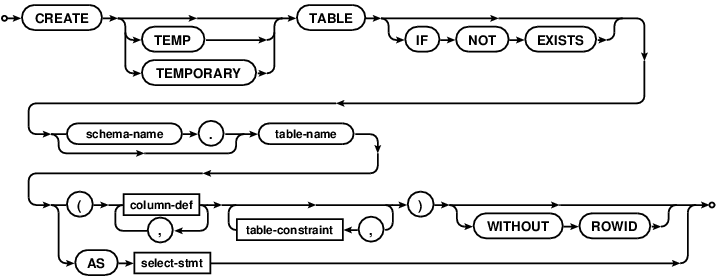

Once you have created a table you’ll probably want to check on its structure. You do this with `DESCRIBE TABLE`.

## 2.3 `INSERT`ing Data into a Table

New records are created with `INSERT`.

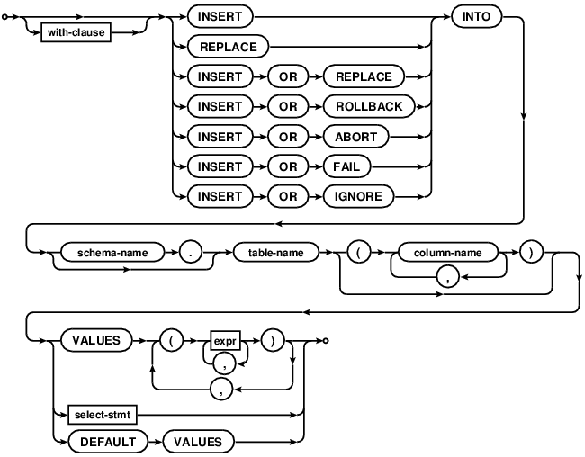

## 2.4 `SELECT`ing from Tables

Queries are executed against a table using `SELECT`.

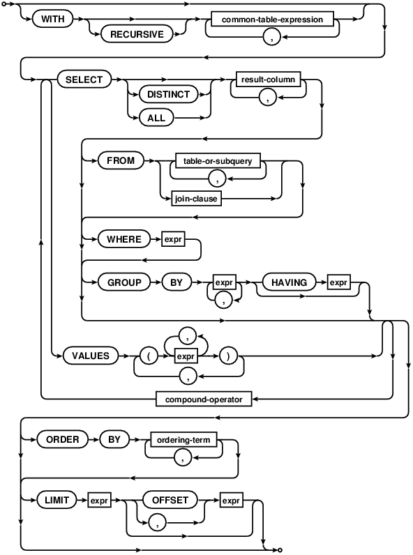

### 2.4.1 Aggregation

Functions, like `SUM()` and `MIN()` can be used to aggregate values. However, they must always be used with a `GROUP BY` clause to indicate how records should be group for aggregation.

For example, suppose that you have a table of employees with `EmployeeId`, `EmployeeGender` and `EmployeeIncome`. You want to analyze differences between male and female employees, so you apply a `GROUP BY` clause on `EmployeeGender` The result will be a table with two records (one for male and the other for female). An aggregation function, perhaps `MIN()`, `MAX()` and `AVG()`, would be applied to the `EmployeeIncome` column.

### 2.4.2 Operators

The `WHERE` clause of a `SELECT` statement is where all of the magic happens. It can be built up as a combination of

- Boolean operators (`AND`, `OR` and `NOT`);
- checking for `IS NULL`;
- arithmetic operators (`+`, `-`, `*`, `/` and `%`);
- relational operatots (`=`, `>`, `<`, `>=` and `<=`);
- checking for a range with `BETWEEN`;
- checking for similarity with `LIKE` and `GLOB` (where the latter is case sensitive);
- checking for set membership with `IN`.

### 2.4.3 `JOIN`ing Tables

A SQL `JOIN` between two tables merges the data from the two tables using one or more common fields. For example, a `JOIN` between the Pets and Owners tables using the common `OwnerId` field could be used to generate the following “denormalised” data:

```
PetName  PetType OwnerName
-------- ------- ---------
Spot     Dog     Megan
Snowball Cat     Arthur
Garfield Cat     Arthur
Rupert   Rat     Megan
```

## 2.5 `UPDATE` Data

Records are amended using `UPDATE`.

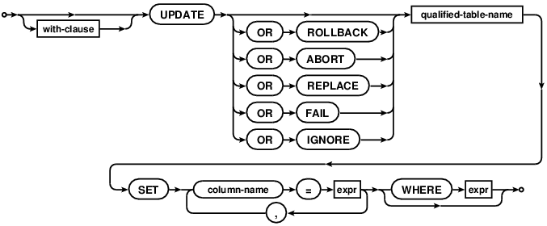

## 2.6 `DELETE` Data

Records are removed using `DELETE`.

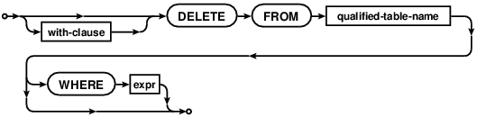

## 2.7 `ALTER`ing a Table

The structure of a table is changed with `ALTER`.

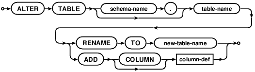

## 2.8 `DROP`ping a Table

A table is removed with `DROP`.

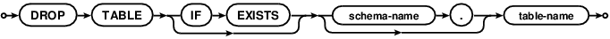

# 3 Accessing a Database from R

R has packages for communicating with most database systems. Of specific interest to us are

- [`RSQLite`](https://cran.r-project.org/web/packages/RSQLite/index.html)
- [`RMySQL`](https://cran.r-project.org/web/packages/RMySQL/index.html)

```r
library(RSQLite)
```

The first step is to create a connection to the database.

```r
db <- dbConnect(dbDriver("SQLite"), dbname = "people.db")
```

We can then generate a list of tables and also list the fields in a particular table.

```r
dbListTables(db)
```

```
[1] "sqlite_sequence" "tb_Person"       "tb_Profession"
```

```r
dbListFields(db, "tb_Person")
```

```
[1] "PersonId"     "Name"         "Gender"       "Height"       "Birth"        "JobId"
[7] "TaxReference"
```

An arbitrary query can be directed to the database using `dbSendQuery()`. This query is executed synchronously but no records are returned.

```r
results <- dbSendQuery(db, "SELECT * FROM tb_Person;")
```

This returns a result set. Records are retrieved using `dbFetch()`. You can choose to grab only a limited number of records.

```r
dbFetch(results, n = 2)               # Retrieve first two rows
```

```
  PersonId   Name Gender Height      Birth JobId TaxReference
1        1 Thomas      M     NA 2001-06-16     1         <NA>
2        2 Andrea      F     NA 2001-06-13     4         <NA>
```

```r
dbHasCompleted(results)
```

```
[1] FALSE
```

Or you can retrieve all remaining records.

```r
dbFetch(results, n = -1)              # Retrieve rest of rows
```

```
  PersonId    Name Gender Height      Birth JobId TaxReference
1        3 Roberta      F     NA 2002-06-25     1 250602X783U2
2        4    Rudy      M  182.5 2001-11-24     2 241101Y129U0
3        5   Maria      F  175.3 2002-06-28     4         <NA>
4        6 Anthony      M  184.7 2001-12-23     1         <NA>
5        7    Carl      M     NA 2001-12-21     1         <NA>
6        8  Thomas      M     NA 2001-06-16     1         <NA>
```

```r
dbHasCompleted(results)
```

```
[1] TRUE
```

Finally, when you are done with that query, free up the resources using `dbClearResult()`.

```r
dbClearResult(results)
```

```
[1] TRUE
```

You can accomplish anything through the `RSQLite` package that you would be able to achieve through the default database client. Furthermore, there is a direct mapping between R data frames and SQLite tables via `dbReadTable()` and `dbWriteTable()`.

```r
dbReadTable(db, "tb_Person")
```

```
  PersonId    Name Gender Height      Birth JobId TaxReference
1        1  Thomas      M     NA 2001-06-16     1         <NA>
2        2  Andrea      F     NA 2001-06-13     4         <NA>
3        3 Roberta      F     NA 2002-06-25     1 250602X783U2
4        4    Rudy      M  182.5 2001-11-24     2 241101Y129U0
5        5   Maria      F  175.3 2002-06-28     4         <NA>
6        6 Anthony      M  184.7 2001-12-23     1         <NA>
7        7    Carl      M     NA 2001-12-21     1         <NA>
8        8  Thomas      M     NA 2001-06-16     1         <NA>
```

# 4 Exercises

1. Consider the following table of race results.

   ```
   race            km first_name   surname   sex  club          age category time
   --------------- -- ------------ --------- ---- ------------- --- -------- --------
   Peace in Africa 10 Nkosikhona   Mhlakwana Male Pumula         22 Open     00:30:21
   Peace in Africa 10 Samuel       Pazangal  Male Maxed Elite       60+      00:31:21
   Peace in Africa 10 Sipho        Mbanjwa   Male Phantane       21 Open     00:31:37
   Peace in Africa 10 Lindokuhle   Sithole   Male Phantane       21 Open     00:32:50
   Peace in Africa 10 Simphiwe     Zulu      Male Born to Run    38 35-39    00:33:29
   Peace in Africa 10 Phiwayinkosi Mthembu   Male Bluff          29 Open     00:35:03
   Peace in Africa 10 Sibusiso     Buthelezi Male Durban Runner  21 Open     00:35:46
   Peace in Africa 10 Mthokozisi   Masondo   Male Oasis Crescent 23 Open     00:36:13
   Peace in Africa 10 Mduduzi      Khumalo   Male Phantane       35 35-39    00:36:24
   Peace in Africa 10 Thokozani    Mbeje     Male Ntunjambili    33 Open     00:36:32
   ```

- Are the data in this table normalised?
- Design a set of tables to efficiently store these data.
2. **Database Design:** You’re the business intelligence analyst setting up a new database instance for products in a sporting goods store.
- What sort of tables would you want (keeping in mind normalization)? List all tables that you think would be relevant.
- What sort of fields would be important to include for each table? Be mindful to specify the primary and foreign keys for each table.
- Suppose that you wanted to find out the name of the product with the lowest price. Write a sample SQL query that would produce that result.
3. **SQLite and R:** Using the `RSQLite` package, download this [SQLite database](https://drive.google.com/open?id=0B3UuwwbJdu0VenBtNmNaRG5nbVU) and write queries on the `Invoice` table.
- Show the number of invoices dated 11 March 2010.
- Show all of the information about the invoice with the highest total during 2009.
- Find the dates of invoices where the billing country is Germany and the invoice total was less than 2.
- Find the average invoice total and number of invoices grouped by billing country and billing city. One record in this results set, for example, could be (and this is a fake output):

  ```
  BillingCity BillingCountry AVG  Count
  ----------- -------------- ---- -----
  Stuttgart   Germany        3.50 15
  ```

- [Challenge Question] Write a query (hint: will use a join) that will return the customer first name, last name, and company of the top ten invoices by total.
4. **SQL JOINS:** Complete the first and last exercise of the [W3Resource SQL JOINs exercises page](http://www.w3resource.com/sql-exercises/sql-joins-exercises.php).
5. **SQL vesus NoSQL:** A large debate in the data science and IT communities is the use of SQL or NoSQL databases.  
   Here is a quick description of NoSQL:

   > A NoSQL database environment is, simply put, a non-relational and largely distributed database system that enables rapid, ad-hoc organization and analysis of extremely high-volume, disparate data types. NoSQL databases are sometimes referred to as cloud databases, non-relational databases, Big Data databases and a myriad of other terms and were developed in response to the sheer volume of data being generated, stored and analyzed by modern users (user-generated data) and their applications (machine-generated data). NoSQL is often used for Big Data projects which handle data which is characterised by high velocity, variety, volume and complexity.

   What database storage solution would you suggest for each of the following scenarios? Why?
- Amazon, one of the world’s largest electronic retailers, which maintains massive customer and transactions databases.
- A small-sized clothing store company that has three locations around Chicago.

# Resources

Batra, Rahul. 2015. *A Primer on SQL*. Leanpub. https://leanpub.com/aprimeronsql.

Shaw, Zed. n.d. *Learn SQL The Hard Way*. http://sql.learncodethehardway.org/book/.